# Reproducible Research Week 2 Project

Xin Ha

3/16/2020

## Load libraries

```r
library(ggplot2)
```

## Load and process the data

#### 1. Unzip and load data

```r
unzip("repdata_data_activity.zip")
activity <- read.csv("activity.csv")
```

#### 2. Calculate total number of steps and rename columns

```r
StepsbyDay <- aggregate(activity$steps, by=list(activity$date), FUN=sum, na.rm=FALSE)
names(StepsbyDay)[1] <- "Date"
names(StepsbyDay)[2] <- "Steps"
```

#### 3. Disply Results

```r
head(StepsbyDay, 61)
```

```
##          Date Steps
## 1  2012-10-01    NA
## 2  2012-10-02   126
## 3  2012-10-03 11352
## 4  2012-10-04 12116
## 5  2012-10-05 13294
## 6  2012-10-06 15420
## 7  2012-10-07 11015
## 8  2012-10-08    NA
## 9  2012-10-09 12811
## 10 2012-10-10  9900
## 11 2012-10-11 10304
## 12 2012-10-12 17382
## 13 2012-10-13 12426
## 14 2012-10-14 15098
```

[output cut: 47 more lines]

#### 4. Plot historgram of total number of steps taken

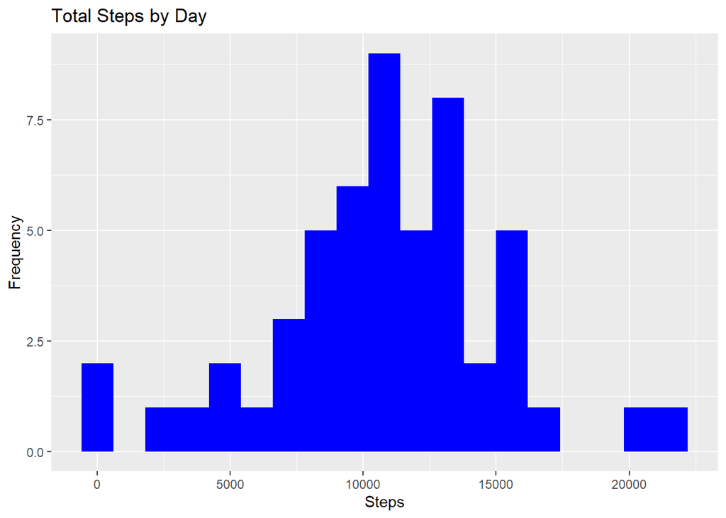

```r
ggplot(StepsbyDay, aes(x = Steps)) +
  geom_histogram(fill = "Blue", binwidth = 1200) +
  labs(title = "Total Steps by Day", x = "Steps", y = "Frequency")
```

### 5. Calculate Mean and Median number of steps per day

```r
meansteps <- mean(StepsbyDay$Steps, na.rm=TRUE)
mediansteps <- median(StepsbyDay$Steps, na.rm=TRUE)
```

## Average daily activity pattern

```r
activityremoveNA <- subset(activity,activity$steps >= 0)
MeanStepsbyInterval <- aggregate(activityremoveNA$steps, by=list(activityremoveNA$interval), FUN=mean)
names(MeanStepsbyInterval)[1] ="Interval"
names(MeanStepsbyInterval)[2] ="Steps"
```

### 1. Make a time series plot of the 5-minute interval (x-axis) and the average number of steps taken, averaged across all days (y-axis)

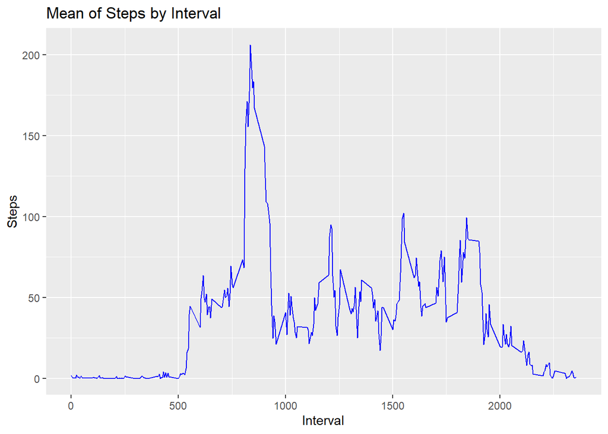

```r
ggplot(MeanStepsbyInterval, aes(x=Interval, y=Steps)) +
  geom_line(color="blue") +
  labs(title = "Mean of Steps by Interval", x = "Interval", y = "Steps")
```

### 2. Which 5-minute interval, on average across all the days in the dataset, contains the maximum number of steps?

```r
maxInterval <- MeanStepsbyInterval[which.max(MeanStepsbyInterval$Steps),]
```

- Maximum mean interval (Interval, Steps): 835, 206.1698113

## Missing Values

### 1. Calculate and report the total number of missing values in the dataset (i.e. the total number of rows with NAs)

```r
numberofNA <- subset(activity,is.na(activity$steps))
missingvalues <- nrow(numberofNA)
```

- Number of missing values: 2304

### 2. Devise a strategy to fill in Missing values.

#### Use the mean of interval to impute missing values.

### 3. Create a new dataset that is equal to the original dataset but with the missing data filled in.

```r
numberofNA <- numberofNA[,c('date','interval')]
numberofNA <- merge(numberofNA,MeanStepsbyInterval,by.x='interval',by.y='Interval')
names(numberofNA)[3] <- 'steps'
activity_imputeNA <- rbind(activityremoveNA,numberofNA)
activity_imputeNA <- activity_imputeNA[order(activity_imputeNA$date,activity_imputeNA$interval),]
```

### 4. Make a histogram of the total number of steps taken each day

```r
StepsByDay2 <- aggregate(activity_imputeNA$steps, by=list(activity_imputeNA$date), FUN=sum, na.rm=FALSE)
names(StepsByDay2)[1] ="Date"
names(StepsByDay2)[2] ="Steps"
head(StepsByDay2,61)
```

```
##          Date    Steps
## 1  2012-10-01 10766.19
## 2  2012-10-02   126.00
## 3  2012-10-03 11352.00
## 4  2012-10-04 12116.00
## 5  2012-10-05 13294.00
## 6  2012-10-06 15420.00
## 7  2012-10-07 11015.00
## 8  2012-10-08 10766.19
## 9  2012-10-09 12811.00
## 10 2012-10-10  9900.00
## 11 2012-10-11 10304.00
## 12 2012-10-12 17382.00
## 13 2012-10-13 12426.00
## 14 2012-10-14 15098.00
```

[output cut: 47 more lines]

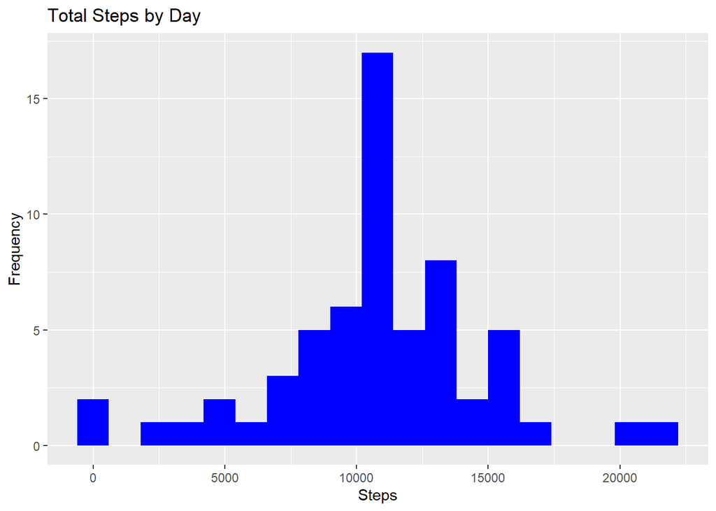

```r
ggplot(StepsByDay2, aes(x = Steps)) +
  geom_histogram(fill = "Blue", binwidth = 1200) +
  labs(title = "Total Steps by Day", x = "Steps", y = "Frequency")
```

### 5. Calculate Mean and Median number of steps per day

```r
meansteps2 <- mean(StepsByDay2$Steps, na.rm=TRUE)
mediansteps2 <- median(StepsByDay2$Steps, na.rm=TRUE)
```

### 6. Do these values differ from the estimates from the first part of the assignment?

Yes, the mean is the same but the median has risen by 1.19 steps.

### 7. What is the impact of imputing missing data on the estimates of the total daily number of steps?

The effect of using mean data per interval as a data imputation method for missing values pushes overall data towards the mean.

## Are there differences in activity patterns between weekdays and weekends?

### 1. Create new variable that gives day of week and whether it is on weekend or not

```r
activity_imputeNA$date <- as.Date(activity_imputeNA$date)
activity_imputeNA$DayofWeek <- weekdays(activity_imputeNA$date)
activity_imputeNA$IsWeekend <- ifelse(activity_imputeNA$DayofWeek == "Saturday" |
                                        activity_imputeNA$DayofWeek == "Sunday", "Weekend", "Weekday")
```

#### Display results

```r
head(activity_imputeNA)
```

```
##        steps       date interval DayofWeek IsWeekend
## 1  1.7169811 2012-10-01        0    Monday   Weekday
## 10 0.3396226 2012-10-01        5    Monday   Weekday
## 17 0.1320755 2012-10-01       10    Monday   Weekday
## 29 0.1509434 2012-10-01       15    Monday   Weekday
## 33 0.0754717 2012-10-01       20    Monday   Weekday
## 45 2.0943396 2012-10-01       25    Monday   Weekday
```

### 2. Time series panel plot

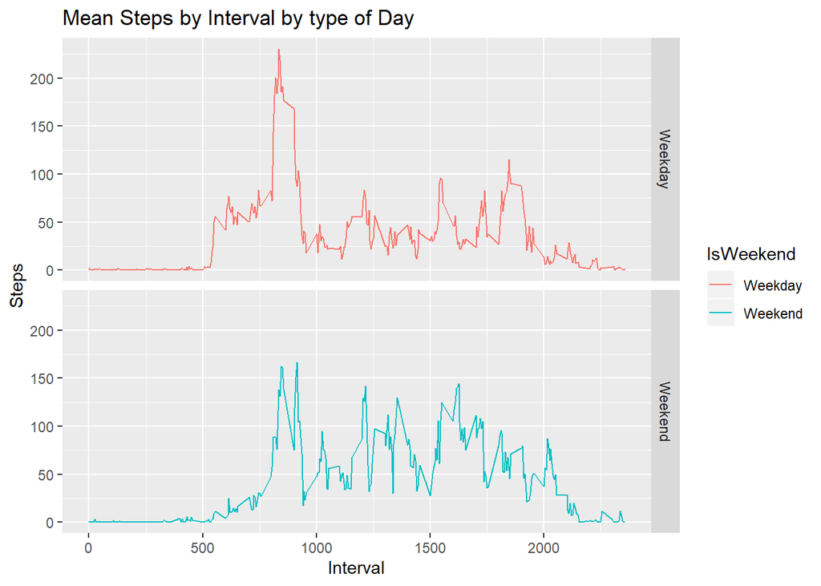

```r
MeanbyIsWeekend <- aggregate(activity_imputeNA$steps,
                             by=list(activity_imputeNA$IsWeekend, activity_imputeNA$interval), mean)
names(MeanbyIsWeekend)[1] ="IsWeekend"
names(MeanbyIsWeekend)[2] ="Interval"
names(MeanbyIsWeekend)[3] ="Steps"
ggplot(MeanbyIsWeekend, aes(x=Interval, y=Steps, color=IsWeekend)) +
  geom_line() +
  facet_grid(IsWeekend ~ .) +
  labs(title="Mean Steps by Interval by type of Day", x = "Interval", y = "Steps")
```